# Morning morality effect

Tremoliere and Gosling

25/03/2021

# 1 - Introduction

```r
 library(ggplot2); library(tidyr); library(dplyr);library(car); library(metafor); library(kableExtra); library(gt); library(lme4); library(lmerTest); library(DescTools); library(stringr)
```

## Loading datasets

```r
Data_Study1_MME <- read.delim(file.choose())
Data_Study2_MME <- read.delim(file.choose())
Data_Study3_MME <- read.delim(file.choose())
Data_Study4_MME <- read.delim(file.choose())
Data_Study5_MME <- read.delim(file.choose())
Data_Study6_MME <- read.delim(file.choose())
```

## Scoring variables

```r
Data_Study1_Raw <- Data_Study1_MME %>%
  dplyr::mutate(
#Check for missing Data
   CCA = case_when(
      is.na(Moral_DIL) | is.na(Heure_TOT) ~ 0,
      !is.na(Moral_DIL) & !is.na(Heure_TOT) ~ 1),
#Detect participants failing at attention check
    Attention_check=case_when(
      Tromp == 2  ~ 1,
      Tromp != 2 ~ 0))

Data_Study2_Raw <- Data_Study2_MME %>%
  mutate(
#Check for missing Data
   CCA = case_when(
      is.na(Moral_SCA) | is.na(Heure_TOT) ~ 0,
      !is.na(Moral_SCA) & !is.na(Heure_TOT) ~ 1),
#Detect participants failing at attention check
    Attention_check = case_when(
      Tromp == 2  ~ 1,
      Tromp != 2 ~ 0))

Data_Study3_Raw <- Data_Study3_MME %>%
  mutate(
#Check for missing Data
   CCA = case_when(
      is.na(Moral_SCA) | is.na(Heure_TOT) ~ 0,
      !is.na(Moral_SCA) & !is.na(Heure_TOT) ~ 1),
#Attention check and sleep efficiency criterion set to 1 since there are none in the task
  Attention_check = 1)

Data_Study4_Raw <- Data_Study4_MME %>%
  mutate(
#Check for missing Data
   CCA = case_when(
      is.na(Moral_DIL) | is.na(Moral_SCA) | is.na(Moral_CAR) | is.na(Heure_TOT) ~ 0,
      !is.na(Moral_DIL) & !is.na(Moral_SCA) & !is.na(Moral_CAR) & !is.na(Heure_TOT) ~ 1),
#Detect participants failing at attention check
    Attention_check=case_when(
      Tromp == 0  ~ 1,
      Tromp == 1 ~ 0))

Data_Study5_Raw <- Data_Study5_MME %>%
  mutate(
#Check for missing Data
   CCA = case_when(
      is.na(Moral_DIL) | is.na(Moral_SCA) | is.na(Heure_TOT) ~ 0,
      !is.na(Moral_DIL) & !is.na(Moral_SCA) & !is.na(Heure_TOT) ~ 1),
#Attention check set to 1 since there are none in the task
   Attention_check = 1)

Data_Study6_Raw <- Data_Study6_MME %>%
  mutate(
#Check for missing Data
   CCA = case_when(
      is.na(Moral_DIL) | is.na(Moral_SCA) | is.na(Heure_TOT) ~ 0,
      !is.na(Moral_DIL) & !is.na(Moral_SCA) & !is.na(Heure_TOT) ~ 1),
#Detect participants failing at attention check
    Attention_check=case_when(
      Tromp == 1 ~ 1,
      Tromp != 1 ~ 0))

# For each dataset, we select only the required columns, we create an outcome column describing the type of outcome used in the study, we create unique participant identifiers, and we set the minimal duration under which the task could not be correctly performed

Data_MetaS1 <- Data_Study1_Raw %>%
  dplyr::select(ResponseId, Moral_DIL,
          Age_correct, Attention_check, CCA, Duration,
          Heure_TOT, AOT_TOT, Narc_TOT, Mach_TOT, Psych_TOT, CRT_TOT, Num_TOT) %>%
  dplyr::mutate(
    Outcome="Dilemmas", Study="1",
    ResponseId=paste0(1:nrow(Data_Study1_Raw), "_S1"),
    Duration.min=200
         )

Data_MetaS2 <- Data_Study2_Raw %>%
  dplyr::select(ResponseId,Moral_SCA,
         Age_correct, Attention_check, CCA, Duration,
         Heure_TOT, AOT_TOT, Narc_TOT, Mach_TOT, Psych_TOT, CRT_TOT, Num_TOT)%>%
  dplyr::mutate(
    Outcome = "Scale",
    Study = "2",
    ResponseId = paste0(1:nrow(Data_Study2_Raw), "_S2"),
    Duration.min = 150
    )

Data_MetaS3 <- Data_Study3_Raw %>%
  dplyr::select(ResponseId, Moral_SCA,
         Age_correct, CCA, Duration, Attention_check, Heure_TOT)%>%
  dplyr::mutate(
    Outcome = "Scale", Study = "3",
    ResponseId = paste0(1:nrow(Data_Study3_Raw), "_S3"),
    Duration.min = 150
    )

Data_MetaS4.wide <- Data_Study4_Raw %>%
  dplyr::select(ResponseId,Moral_DIL, Moral_SCA, Moral_CAR,
                Age_correct, Attention_check, CCA, Duration, Heure_TOT)%>%
  dplyr::mutate(
    Study = "4",
    ResponseId = paste0(1:nrow(Data_Study4_Raw), "_S4"),
    Duration.min = 200
    )

Data_MetaS4 <- Data_MetaS4.wide %>%
  pivot_longer(cols=c("Moral_DIL", "Moral_SCA", "Moral_CAR"), values_to="Moral_TOT",
               names_to="Outcome_transit") %>%
  dplyr::mutate(Outcome=case_when(
           Outcome_transit=="Moral_DIL"~"Dilemmas",
           Outcome_transit=="Moral_SCA"~"Scale",
           Outcome_transit=="Moral_CAR"~"Autonomouscars"))

Data_MetaS5.wide<-Data_Study5_Raw %>%
  dplyr::select(ResponseId,Moral_DIL, Moral_SCA,
                Age_correct, CCA, Duration, Attention_check, Heure_TOT) %>%
   dplyr::mutate(Study="5",
         ResponseId=paste0(1:nrow(Data_Study5_Raw), "_S5"),
         Duration.min=150,
         )

Data_MetaS5<- Data_MetaS5.wide %>%
  pivot_longer(cols=c("Moral_DIL", "Moral_SCA"), values_to="Moral_TOT", names_to="Outcome_transit") %>%
   dplyr::mutate(Outcome=case_when(
           Outcome_transit=="Moral_DIL"~"Dilemmas",
           Outcome_transit=="Moral_SCA"~"Scale"))

Data_MetaS6.wide<-Data_Study6_Raw %>%
   dplyr::select(ResponseId,Moral_DIL, Moral_SCA,
                 Age_correct, CCA, Attention_check, Duration, SleepEfficiency.criteria, Heure_TOT) %>%
  dplyr::mutate(Study="6",
         ResponseId=paste0(1:nrow(Data_Study6_Raw), "_S6"),
         Duration.min=150
         )

Data_MetaS6<- Data_MetaS6.wide %>%
  pivot_longer(cols=c("Moral_DIL", "Moral_SCA"), values_to="Moral_TOT", names_to="Outcome_transit") %>%
   dplyr::mutate(Outcome=case_when(
           Outcome_transit=="Moral_DIL"~"Dilemmas",
           Outcome_transit=="Moral_SCA"~"Scale"))
```

Creating a an unique datasets combining all 6 studies

```r
# we create 3 datasets with one row per participant
# one dataset with all participants
Data_Meta_Raw_transit.wide<- bind_rows(
  Data_MetaS1, Data_MetaS2, Data_MetaS3, Data_MetaS4.wide, Data_MetaS5.wide, Data_MetaS6.wide)

# one dataset with participants who have no missing values
Data_Meta_Raw.wide_CCA <- filter(Data_Meta_Raw_transit.wide, CCA==1)

# one dataset with participants who have who have no missing values, correct sleep efficiency ratio and credible sleep quantity
Data_Meta_Raw.wide_CCA_excl1 <- filter(Data_Meta_Raw.wide_CCA,
                                       Heure_TOT >= 8 & Heure_TOT <=18)

# one dataset with participants who have who have no missing values, correct sleep efficiency ratio, credible sleep quantity and correct attentional check
Data_Meta_Raw.wide<-filter(Data_Meta_Raw.wide_CCA_excl1, Attention_check==1)

# we create a dataset with one row per outcome per participant
# For example, in a study with 3 outcomes, a participants will have 3 rows
Data_Meta_Raw.long <- Data_Meta_Raw.wide %>%
  pivot_longer(
    cols = c(Moral_DIL, Moral_SCA, Moral_CAR),
    names_to = "Moral_name",
    values_to = "Moral_TOT") %>%
  filter(!is.na(Moral_TOT))
```

## Participants

```r
# we work on raw datasets regardless the missing values or the correctness of the attention check
list_data_demographics <- list(
  Data_Study1_Raw, Data_Study2_Raw, Data_Study3_Raw, Data_Study4_Raw, Data_Study5_Raw, Data_Study6_Raw
)

#  we create a function extracting the total number of participants, the number of participants with no missing value and the participants with a correct attentional check in each study. We also extracted the percentage of female.

DEMOFUNCTION<-function(x){
  N.TOT = nrow(x)
  N.hour = nrow(subset(x, Heure_TOT >= 8 & Heure_TOT <=18))
  N.CCA = nrow(subset(x, Heure_TOT >= 8 & Heure_TOT <=18)) - nrow(subset(x, Heure_TOT >= 8 & Heure_TOT <=18 & CCA==1))
  N.attcheck = nrow(subset(x, Heure_TOT >= 8 & Heure_TOT <=18 & CCA == 1)) - nrow(subset(x, Heure_TOT >= 8 & Heure_TOT <=18 & CCA == 1 & Attention_check == 1))
  N.Analysis = nrow(subset(x, Heure_TOT >= 8 & Heure_TOT <=18 & CCA == 1 & Attention_check == 1))
  Perc.Female = 1  - nrow(subset(x, Gender == 1))/nrow(x)
  cbind(N.TOT, N.hour, N.CCA, N.attcheck, N.Analysis, Perc.Female)
  }

data_demographics<-data.frame(do.call(rbind, lapply(list_data_demographics, DEMOFUNCTION)))

Data_presentation <- data.frame(
  Study=1:6,
  data_demographics)

colnames(Data_presentation)<-c(
  "Study",
  "Total number of participants",
  "Number of participants assessed in the 8:00am-6:00pm range",
  "Number of participants with missing values",
  "Number of participants with an incorrect attentional check",
  "Number of participants retained in final analysis",
  "% of female")

gt(Data_presentation)
```

| Study | Total number of participants | Number of participants assessed in the 8:00am-6:00pm range | Number of participants with missing values | Number of participants with an incorrect attentional check | Number of participants retained in final analysis | % of female |
| --- | --- | --- | --- | --- | --- | --- |
| 1 | 124 | 123 | 0 | 2 | 121 | 0.4032258 |
| 2 | 115 | 108 | 0 | 7 | 101 | 0.4086957 |
| 3 | 54 | 18 | 0 | 0 | 18 | 0.8703704 |
| 4 | 123 | 111 | 0 | 11 | 100 | 0.3658537 |
| 5 | 121 | 48 | 0 | 0 | 48 | 0.7107438 |
| 6 | 105 | 104 | 0 | 4 | 100 | 0.7523810 |

# 2 - Primary analysis

## Functions

Function performing correlations depending on the study

```r
CorS1<-function(x){
     cor(dplyr::select(x,
             Moral_DIL,
             Heure_TOT))}

CorS2S3<-function(x){
     cor(dplyr::select(x,
             Moral_SCA,
             Heure_TOT))}

CorS4<-function(x){
     cor(dplyr::select(x,
             Moral_DIL,
             Moral_SCA,
             Moral_CAR,
             Heure_TOT))}

CorS5S6<-function(x){
     cor(dplyr::select(x,
           Moral_DIL,
           Moral_SCA,
           Heure_TOT))}

CorFUNCTION <- function(x) {
  ifelse(unique(x$Study)==1,
    COR <- CorS1(x),
    ifelse(unique(x$Study) %in% c(2,3),
       COR<- CorS2S3(x),
        ifelse(unique(x$Study)==4,
          COR<- CorS4(x),
            ifelse(unique(x$Study) %in% c(5,6),
              COR<- CorS5S6(x),
      NA))))
   COR}
```

Function computing variance/covariance matrix based on the equation approach (Steiger, 1980). All the credit for this function should be given to Pr Wolfgang Viechtbauer.

```r
rmat <- function(x, n, upper=TRUE, simplify=TRUE, rtoz=TRUE, data) {

   if (inherits(x, "formula")) {

      options(na.action = "na.pass")

      if (missing(data))
         stop("Must specify 'data' argument when 'x' is a formula.")

      if (!is.data.frame(data))
         data <- data.frame(data)

      dat <- get_all_vars(x, data=data)

      if (ncol(dat) != 4)
         stop("Incorrect number of variables specified in formula.")

      id <- dat[,4]
      dat <- split(dat, id)

      res <- list()

      for (i in 1:length(dat)) {

         ri <- dat[[i]][[1]]
         var1 <- as.character(dat[[i]][[2]])
         var2 <- as.character(dat[[i]][[3]])

         vars <- sort(unique(c(var1, var2)))

         R <- matrix(NA, nrow=length(vars), ncol=length(vars))
         diag(R) <- 1
         rownames(R) <- colnames(R) <- vars

         for (j in 1:length(var1)) {
            R[var1[j],var2[j]] <- R[var2[j],var1[j]] <- ri[j]
         }

         res[[i]] <- R

      }

      return(rmat(res, n=n, simplify=TRUE, rtoz=rtoz))

   }

   if (is.list(x)) {

      k <- length(x)

      if (length(x) != length(n))
         stop("Argument 'n' must be of the same length as there are elements in 'x'.")

      res <- list()

      for (i in 1:k) {
         res[[i]] <- rmat(x[[i]], n[i], upper=upper, rtoz=rtoz)
      }

      if (simplify) {
         ki <- sapply(res, function(x) ifelse(is.null(x$dat), 0, nrow(x$dat)))
         dat <- cbind(id=rep(1:k, times=ki), do.call(rbind, lapply(res, "[[", "dat")))
         V <- bldiag(lapply(res[ki > 0], "[[", "V"))
         rownames(V) <- colnames(V) <- unlist(lapply(res, function(x) rownames(x$V)))
         return(list(dat=dat, V=V))
      } else {
         return(res)
      }

   }

   if (!is.matrix(x))
      stop("Argument 'x' must be a matrix (or list thereof).")

   if (dim(x)[1] != dim(x)[2])
      stop("Argument 'x' must be a square matrix (or list thereof).")

   dimsx <- nrow(x)
   dnames <- paste0("x", 1:dimsx)

   ### in case x has dimension names, use those

   if (!is.null(rownames(x)))
      dnames <- rownames(x)
   if (!is.null(colnames(x)))
      dnames <- colnames(x)

   ### in case x is a 1x1 (or 0x0) matrix, return nothing

   if (dimsx <= 1L)
      return(list(dat=NULL, V=NULL))

   ### make x symmetric, depending on whether we use upper or lower part

   if (upper) {
      x[lower.tri(x)] <- t(x)[lower.tri(x)]
   } else {
      x[upper.tri(x)] <- t(x)[upper.tri(x)]
   }

   ### check if x is symmetric (can be skipped since x must now be symmetric)

   #if (!isSymmetric(x))
   #   stop("x must be a symmetric matrix.")

   ### stack upper/lower triangular part of x into a column vector (this is always done column-wise!)

   if (upper) {
      ri <- cbind(x[upper.tri(x)])
   } else {
      ri <- cbind(x[lower.tri(x)])
   }

   ### apply r-to-z transformation if requested

   if (rtoz)
      ri <- 1/2 * log((1 + ri)/(1 - ri))

   ### I and J are matrices with 1:dimsx for rows and columns, respectively

   I <- matrix(1:dimsx, nrow=dimsx, ncol=dimsx)
   J <- matrix(1:dimsx, nrow=dimsx, ncol=dimsx, byrow=TRUE)

   ### get upper/lower triangular elements of I and J

   if (upper) {
      I <- I[upper.tri(I)]
      J <- J[upper.tri(J)]
   } else {
      I <- I[lower.tri(I)]
      J <- J[lower.tri(J)]
   }

   ### dimensions in V (must be dimsx*(dimsx-1)/2)

   dimsV <- length(ri)

   ### set up V matrix

   V <- matrix(NA, nrow=dimsV, ncol=dimsV)

   for (ro in 1:dimsV) {
      for (co in 1:dimsV) {

         i <- I[ro]
         j <- J[ro]
         k <- I[co]
         l <- J[co]

         ### Olkin & Finn (1995), equation 5, page 157

         V[ro,co] <- 1/2 * x[i,j]*x[k,l] * (x[i,k]^2 + x[i,l]^2 + x[j,k]^2 + x[j,l]^2) +
                     x[i,k]*x[j,l] + x[i,l]*x[j,k] -
                     (x[i,j]*x[i,k]*x[i,l] + x[j,i]*x[j,k]*x[j,l] + x[k,i]*x[k,j]*x[k,l] + x[l,i]*x[l,j]*x[l,k])

         ### Steiger (1980), equation 2, page 245 (provides the same result - checked)

         #V[ro,co] <- 1/2 * ((x[i,k] - x[i,j]*x[j,k]) * (x[j,l] - x[j,k]*x[k,l]) +
         #                   (x[i,l] - x[i,k]*x[k,l]) * (x[j,k] - x[j,i]*x[i,k]) +
         #                   (x[i,k] - x[i,l]*x[l,k]) * (x[j,l] - x[j,i]*x[i,l]) +
         #                   (x[i,l] - x[i,j]*x[j,l]) * (x[j,k] - x[j,l]*x[l,k]))

         ### Steiger (1980), equation 11, page 247 for r-to-z transformed values

         if (rtoz)
            V[ro,co] <- V[ro,co] / ((1 - x[i,j]^2) * (1 - x[k,l]^2))

      }
   }

   ### divide V by (n-1) for raw correlations and by (n-3) for r-to-z transformed correlations

   if (rtoz) {
      V <- V/(n-3)
   } else {
      V <- V/(n-1)
   }

   ### create matrix with var1 and var2 names and sort rowwise

   dmat <- cbind(dnames[I], dnames[J])
   dmat <- t(apply(dmat, 1, sort))

   ### set row/column names for V

   var1var2 <- paste0(dmat[,1], ".", dmat[,2])
   rownames(V) <- colnames(V) <- var1var2

   return(list(dat=data.frame(yi=ri, var1=dmat[,1], var2=dmat[,2], var1var2=var1var2, stringsAsFactors=FALSE), V=V))

}
```

Function computing the correlation and variance/covariance matrix while converting Pearson’s r to Fisher’s Z

```r
 RmatFUNCTION<-function(x,y){
   rmat(x, n=y, rtoz=TRUE)}
```

Function extracting confidence intervals for correlations

```r
CorCIFUNCTION<-function(x,y){
  CorCI(x,y, conf.level = (1-(0.05)))
}
```

Function extracting critical information from meta analyses (performed using metafor)

```r
ExtractMetaFUNCTION<-function(x){
  cbind(
     Raw.r = FisherZInv(as.numeric(as.character(x$b))),
     p.val = as.numeric(as.character(x$pval)),
     Adj.p.val=as.numeric(as.character(x$pval)),
     CIlow=FisherZInv(x$ci.lb),
     CIup=FisherZInv(x$ci.ub),
     TOST1=abs(FisherZInv(as.numeric(as.character(x$b))-as.numeric(as.character(x$se*qnorm(1-2*(0.05/(2))))))),
     TOST2=abs(FisherZInv(as.numeric(as.character(x$b))+as.numeric(as.character(x$se*qnorm(1-2*(0.05/(2))))))),
     Cochran.Q=x$QE,
     Cochran.Q.p.val=x$QEp)
}
```

Function extracting critical information about heterogeneity

```r
# x is the rma object and y the variance covariance matrix
ExtractHeterogeneityFUNCTION<-function(x, y){
     W<-solve(y)
     X<-model.matrix(x)
     P <- W - W %*% X %*% solve(t(X) %*% W %*% X) %*% t(X) %*% W
     cbind(
       stud.out=as.character(data.frame(x$g.levels.k)[,1]),
       N=data.frame(x$g.levels.k)[,2],
       Tau.sq=x$tau2,
       Tau=sqrt(x$tau2),
       Cochran.Q=x$QE,
       Cochran.Q.p.val=x$QEp,
       I.sq=100 *x$tau2 / (x$tau2 + (x$k-x$p)/sum(diag(P))))
}
```

Functions selecting appropriate data in the correlation or variance/covariance matrix (i.e., information regarding only the relationship between sleep and moral outcomes and not those regarding - for example - the relationship between 2 sleep indicators)

```r
PredictFUNCTION<-function(x){
x[str_detect(row.names(x), "Heure") & str_detect(row.names(x), "Moral"),
  str_detect(colnames(x), "Heure") & str_detect(colnames(x), "Moral")]}
```

## Primary analysis (code)

Multivariate random effects meta analysis (var-covar matrix estimated using equation based approach)

Preparation of the general dataset. We split the large dataset including the 6 studies as required by most of the functions of the apply family

```r
Data_Meta_Raw.wide.split <- split(Data_Meta_Raw.wide, Data_Meta_Raw.wide$Study)
```

Obtaining sample size for each dataset (here, it is equal to the number of rows since we have evicted participants not retained in final analyses (i.e., those with missing values or incorrect attentional check)

```r
N.prim <- sapply(Data_Meta_Raw.wide.split, nrow)
```

Obtention of Correlation matrix and variance-Covariance matrix for each study

```r
Cor.matrix.prim <- lapply(Data_Meta_Raw.wide.split, CorFUNCTION)

List.Cor.Varcovar.prim <- mapply(RmatFUNCTION, Cor.matrix.prim, N.prim, SIMPLIFY = FALSE)
```

Performing multivariate meta analysis

```r
# Correlation (Fisher's z) between all sleep indicators and all outcomes for each study

ES.prim_transit<-do.call(rbind, lapply(List.Cor.Varcovar.prim, function(x) x$dat))

ES.prim_transit1<-data.frame(cbind(
  stud.out=row.names(ES.prim_transit), ES.prim_transit))

ES.prim_transit2<-separate(ES.prim_transit1, stud.out,
                          into=c("Study"))

# Here, we delete all correlations not regarding sleep-moral outcomes relationship (k=40)

ES.Prim<-ES.prim_transit2 %>%
  rename("Outcome" = var2,
         "Predictor" = var1,
         "Out.Pred" = var1var2) %>%
  mutate(
    Asso.of.int = case_when(
      str_detect(Outcome, "Heure") & str_detect(Predictor, "Moral") ~ 1,
      str_detect(Outcome, "Moral") & str_detect(Predictor, "Heure") ~ 1)) %>%
  filter(Asso.of.int == 1)

ES.Prim$N <- rep(N.prim, c(1, 1,1,3,2,2))

ES.Prim$ES.ID<-1:nrow(ES.Prim)

#Variance-covariance matrix for each study (N=6)
List.Varcovar.prim_transit1<-lapply(List.Cor.Varcovar.prim, function(x) x$V)

# we apply the Predictfunction to keep only associations of interest
List.Varcovar.prim<-lapply(List.Varcovar.prim_transit1, PredictFUNCTION)

V.Prim = bldiag(list(
  List.Varcovar.prim[[1]],
  List.Varcovar.prim[[2]],
  List.Varcovar.prim[[3]],
  List.Varcovar.prim[[4]],
  List.Varcovar.prim[[5]],
  List.Varcovar.prim[[6]]))

# Primary analysis
Meta.Prim<-rma.mv(yi, V.Prim,
                  random = ~ Out.Pred | Study,
                  struct = "UN",
                  data = ES.Prim)

# moderation analysis
Meta.sec <- rma.mv(yi, V.Prim,
                  mods = ~Outcome - 1,
                  random = ~ Out.Pred | Study,
                  struct = "UN",
                  data = ES.Prim)
```

## Primary analysis (results)

```r
#individual studies
ES.Prim$Raw.r<-FisherZInv(ES.Prim$yi)

df.ES.Prim<-data.frame(cbind(
  ES.Prim,
  t(apply(ES.Prim[,c('Raw.r','N')], 1,
          function(x) CorCIFUNCTION(x[1], x[2])))[,c('lwr.ci','upr.ci')]))

colnames(df.ES.Prim)[c(10:11)] <- c("CIlow", "CIup")

#Meta-analyses
df.Meta.Res1.Prim<-as.data.frame(ExtractMetaFUNCTION(Meta.Prim))

df.Meta.Prim.z<- df.Meta.Res1.Prim %>%
  dplyr::mutate(
    Study="Pooled Effect Size",
    Outcome="All outcomes",
    N=sum(N.prim)) %>%
  rowwise() %>%
  dplyr::mutate(TOST=max(TOST1, TOST2)) %>%
  dplyr::select(-c(TOST1,TOST2))

df.Meta.Prim <- df.Meta.Prim.z[,c(8:10,1:2, 4:7, 11)]


df.Results.Prim <- data.frame(bind_rows(df.Meta.Prim, df.ES.Prim[,-c(3,5,6)]))

df.Results.Prim$Outcome <- dplyr::recode(df.Results.Prim$Outcome,
                                  Moral_DIL="Dilemmas",
                                  Moral_SCA="Scale",
                                  Moral_CAR="Autonomous.Cars")

#Summary of the meta analysis
gt(df.Results.Prim[1,1:10])%>%
  fmt_number(
    columns = 4:10,
    decimals = 3)
```

| Study | Outcome | N | Raw.r | p.val | CIlow | CIup | Cochran.Q | Cochran.Q.p.val | TOST |
| --- | --- | --- | --- | --- | --- | --- | --- | --- | --- |
| Pooled Effect Size | All outcomes | 488 | −0.135 | 0.025 | −0.249 | −0.017 | 23.545 | 0.005 | 0.231 |

```r
#Summary of the primary studies
gt(df.Results.Prim[2:nrow(df.Results.Prim),c(
  'Study', 'Outcome', 'N', 'Raw.r', 'CIlow', 'CIup')]) %>%
  fmt_number(
    columns = 4:6,
    decimals = 3)
```

| Study | Outcome | N | Raw.r | CIlow | CIup |
| --- | --- | --- | --- | --- | --- |
| 1 | Dilemmas | 121 | −0.184 | −0.351 | −0.006 |
| 2 | Scale | 101 | 0.041 | −0.155 | 0.235 |
| 3 | Scale | 18 | −0.189 | −0.603 | 0.305 |
| 4 | Dilemmas | 100 | −0.254 | −0.429 | −0.060 |
| 4 | Scale | 100 | 0.019 | −0.178 | 0.214 |
| 4 | Autonomous.Cars | 100 | 0.059 | −0.139 | 0.253 |
| 5 | Dilemmas | 48 | −0.293 | −0.533 | −0.010 |
| 5 | Scale | 48 | −0.209 | −0.465 | 0.080 |
| 6 | Dilemmas | 100 | 0.015 | −0.182 | 0.210 |
| 6 | Scale | 100 | 0.239 | 0.045 | 0.416 |

## Primary analysis (plot)

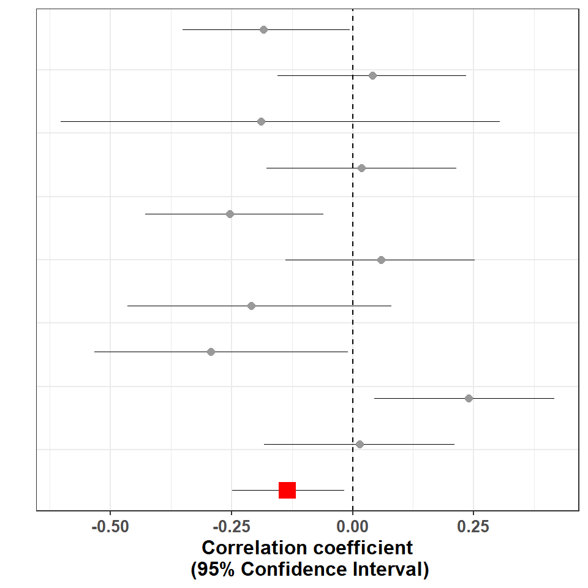

```r
df.graph.prim <- df.Results.Prim
df.graph.prim$pooled <- factor(ifelse(df.graph.prim$Outcome == "All outcomes", 1, 0))
df.graph.prim$Study <- factor(df.graph.prim$Study)
df.graph.prim$Study <- factor(df.graph.prim$Study,
  levels=rev(levels(df.graph.prim$Study)))

df.graph.prim2 <- df.graph.prim[order(df.graph.prim$Outcome),]

p<-ggplot(data=df.graph.prim2) +
  geom_hline(yintercept =0, linetype=2) +
  geom_pointrange(position=position_dodge2(width=8),
                  aes(x = Study, y = Raw.r,
                       ymin = CIlow, ymax = CIup), size = 0)+
  geom_point(aes(x = Study, y = Raw.r, color=pooled, size=pooled, fill = pooled, shape = pooled),
              position=position_dodge2(width=8))+
  xlab('')+ ylab("Correlation coefficient\n (95% Confidence Interval)")+
  scale_color_manual(values=c("#999999", "red")) +
  scale_fill_manual(values=c("#999999", "red")) +
  scale_size_manual(values=c(2, 5)) +
  scale_shape_manual(values=c(21, 22)) +
  coord_flip()+
  theme_bw() +
  theme(legend.position="right",
          axis.text.y=element_blank(),
          axis.ticks.y=element_blank(),
          axis.text.x=element_text(size=10, face="bold"),
          axis.title.y=element_text(size=12,face="bold"),
          axis.title.x=element_text(size=12,face="bold"),
          strip.text.x = element_text(hjust=0.5,vjust =0.5,angle=0,
                                      size= 11),
          legend.background = element_rect(size = 0.5, linetype = "solid",
                                  colour ="black"),
        legend.box = "vertical")

p+guides(fill = FALSE, color = FALSE, shape = FALSE, size = FALSE,linetype = FALSE)# shape=FALSE,
```

# 3 - Exploration of heterogeneity

```r
df.Meta.Res1.sec<-as.data.frame(ExtractMetaFUNCTION(Meta.sec))

df.Meta.sec.z<- df.Meta.Res1.sec %>%
  dplyr::mutate(
    Study="Pooled Effect Size",
    Outcome= c("Autonomous cars", "Dilemmas", "Scale"),
    N= c(N.prim[4], sum(N.prim[c(1,4,5,6)]), sum(N.prim[c(2:6)]))) %>%
  rowwise() %>%
  dplyr::mutate(TOST=max(TOST1, TOST2)) %>%
  dplyr::select(-c(TOST1,TOST2))

Heterogeneity.sec <- as.data.frame(ExtractHeterogeneityFUNCTION(Meta.sec, V.Prim))
Heterogeneity.sec2 <- data.frame(apply(Heterogeneity.sec[,3:7], 2, function(x) as.numeric(as.character(x))))

df.Meta.sec <- cbind(df.Meta.sec.z[,c(8:10,1:2, 4:7, 11)], 'I-square' = paste0(round(Heterogeneity.sec2$I.sq, 2), "%"))

#Summary of the meta analysis
gt(df.Meta.sec[2:3, 1:11])%>%
  fmt_number(
    columns = 4:10,
    decimals = 3)
```

| Study | Outcome | N | Raw.r | p.val | CIlow | CIup | Cochran.Q | Cochran.Q.p.val | TOST | I-square |
| --- | --- | --- | --- | --- | --- | --- | --- | --- | --- | --- |
| Pooled Effect Size | Dilemmas | 369 | −0.184 | 0.005 | −0.308 | −0.055 | 10.172 | 0.179 | 0.288 | 42.28% |
| Pooled Effect Size | Scale | 367 | 0.033 | 0.643 | −0.106 | 0.171 | 10.172 | 0.179 | 0.149 | 50.17% |

```r
# Heterogeneity
gt(Heterogeneity.sec2[2:3, ])%>%
  fmt_number(
    columns = 1:5,
    decimals = 3)
```

| Tau.sq | Tau | Cochran.Q | Cochran.Q.p.val | I.sq |
| --- | --- | --- | --- | --- |
| 0.009 | 0.093 | 10.172 | 0.179 | 42.281 |
| 0.012 | 0.109 | 10.172 | 0.179 | 50.174 |

```r
gt(df.Results.Prim[df.Results.Prim$Outcome=="Dilemmas", c(1:4, 6:7)])
```

| Study | Outcome | N | Raw.r | CIlow | CIup |
| --- | --- | --- | --- | --- | --- |
| 1 | Dilemmas | 121 | -0.18390071 | -0.3508794 | -0.005587593 |
| 4 | Dilemmas | 100 | -0.25380836 | -0.4288473 | -0.060401412 |
| 5 | Dilemmas | 48 | -0.29296167 | -0.5327500 | -0.009628447 |
| 6 | Dilemmas | 100 | 0.01452616 | -0.1824124 | 0.210344124 |

```r
gt(df.Results.Prim[df.Results.Prim$Outcome=="Scale", c(1:4, 6:7)])
```

| Study | Outcome | N | Raw.r | CIlow | CIup |
| --- | --- | --- | --- | --- | --- |
| 2 | Scale | 101 | 0.04129509 | -0.15539834 | 0.23483905 |
| 3 | Scale | 18 | -0.18913693 | -0.60278009 | 0.30463295 |
| 4 | Scale | 100 | 0.01876427 | -0.17831104 | 0.21439221 |
| 5 | Scale | 48 | -0.20889468 | -0.46540559 | 0.07998762 |
| 6 | Scale | 100 | 0.23945705 | 0.04516312 | 0.41629526 |

# 4 - Secondary analysis

## Confounding variables

```r
df.S1 <- Data_Meta_Raw.wide[Data_Meta_Raw.wide$Study == 1,]
df.S1$Psych_Z <- (df.S1$Psych_TOT - mean(df.S1$Psych_TOT))/sd(df.S1$Psych_TOT)
df.S1$Mach_Z <- (df.S1$Mach_TOT - mean(df.S1$Mach_TOT))/sd(df.S1$Mach_TOT)
df.S1$Narc_Z <- (df.S1$Narc_TOT - mean(df.S1$Narc_TOT))/sd(df.S1$Narc_TOT)
df.S1$DT <- with(df.S1, Psych_Z + Mach_Z + Narc_Z)

cor.S1 <- cor.test(~Heure_TOT + Moral_DIL, df.S1)
lm.S1.crude <- lm(Moral_DIL~Heure_TOT, df.S1)
lm.S1.adj.CRT <- lm(Moral_DIL~Heure_TOT+CRT_TOT, df.S1)
lm.S1.adj.Psych1 <- lm(Moral_DIL~Heure_TOT+Psych_Z, df.S1)
lm.S1.adj.Mach1 <- lm(Moral_DIL~Heure_TOT+Mach_Z, df.S1)
lm.S1.adj.Narc1 <- lm(Moral_DIL~Heure_TOT+Narc_Z, df.S1)
lm.S1.adj.AOT <- lm(Moral_DIL~Heure_TOT+AOT_TOT, df.S1)
lm.S1.adj.DT<- lm(Moral_DIL ~ Heure_TOT+DT, df.S1)

res.S1 <- rbind(
  broom::tidy(lm.S1.crude)[2,],
  broom::tidy(lm.S1.adj.CRT)[2,],
  broom::tidy(lm.S1.adj.Psych1)[2,],
  broom::tidy(lm.S1.adj.Mach1)[2,],
  broom::tidy(lm.S1.adj.Narc1)[2,],
  broom::tidy(lm.S1.adj.DT)[2,],
  broom::tidy(lm.S1.adj.AOT)[2,])
res.S1$control <- c("crude", "CRT", "Psychopathy", "Machiavelism", "Narcissism", "Dark Triad", "AOT")
res.S1$modification <- c(
  NA_real_,
  anova(lm.S1.crude, lm.S1.adj.CRT)$'Pr(>F)'[2],
  anova(lm.S1.crude, lm.S1.adj.Psych1)$'Pr(>F)'[2],
  anova(lm.S1.crude, lm.S1.adj.Mach1)$'Pr(>F)'[2],
  anova(lm.S1.crude, lm.S1.adj.Narc1)$'Pr(>F)'[2],
  anova(lm.S1.crude, lm.S1.adj.DT)$'Pr(>F)'[2],
  anova(lm.S1.crude, lm.S1.adj.AOT)$'Pr(>F)'[2]
  )

gt(res.S1) %>%
  fmt_number(
    columns = c(2:5,7),
    decimals = 3)
```

| term | estimate | std.error | statistic | p.value | control | modification |
| --- | --- | --- | --- | --- | --- | --- |
| Heure_TOT | −4.246 | 2.081 | −2.041 | 0.043 | crude | NA |
| Heure_TOT | −3.855 | 2.126 | −1.813 | 0.072 | CRT | 0.367 |
| Heure_TOT | −2.840 | 2.142 | −1.326 | 0.187 | Psychopathy | 0.028 |
| Heure_TOT | −3.355 | 2.057 | −1.631 | 0.106 | Machiavelism | 0.009 |
| Heure_TOT | −4.092 | 2.089 | −1.959 | 0.052 | Narcissism | 0.365 |
| Heure_TOT | −3.100 | 2.093 | −1.481 | 0.141 | Dark Triad | 0.017 |
| Heure_TOT | −4.043 | 2.110 | −1.917 | 0.058 | AOT | 0.524 |

## One-stage meta-analysis

```r
Meta.S3 <- lmerTest::lmer(Moral_TOT ~ Heure_TOT + (Heure_TOT:Moral_name - 1 | Study), data = Data_Meta_Raw.long)
```

```
## boundary (singular) fit: see ?isSingular
```

```r
df.Meta.S3 <- broom.mixed::tidy(Meta.S3, conf.int = TRUE, conf.level = 1-0.05, effects = "fixed")
df.Meta.S3
```

```
## # A tibble: 2 x 9
##   effect term     estimate std.error statistic    df  p.value conf.low conf.high
##   <chr>  <chr>       <dbl>     <dbl>     <dbl> <dbl>    <dbl>    <dbl>     <dbl>
## 1 fixed  (Interc~   42.9       3.61      11.9   626. 2.15e-29    35.8    49.9
## 2 fixed  Heure_T~   -0.640     0.293     -2.19  653. 2.91e- 2    -1.21   -0.0664
```